# Clustering with Anonymized PBS On-Demand Viewing Data

Natalie Benoy

7/27/2022

### About this dataset:

This is a dataset containing on-demand streaming data of PBS programs by active donors of PBS Utah. Streaming data has been collected from the PBS Video App, for a period of time between December 2020 and March 2022. Variables include:

- Content.Channel (program streamed)
- Device
- Unique identifier variable (ID) associated with unique viewer email addresses (which have been removed for privacy reasons)

### Goals of this project:

The goal of this project was to use unsupervised learning, in this case clustering, to segment users by viewing behavior. In doing so, we hope to:

- learn more about PBS Utah member viewing trends
- obtain defined clusters into which new members can be assigned
- use the new cluster assignments to send targeted email communications to streaming members of PBS Utah, with program recommendations based on cluster assignment

### Load data and packages

```r
library(tidyverse)
library(ggplot2)

# Import cleaned and anonymized dataset, with unecessary, redundant, or personally identifiable variables like UID, Membership.ID, TP.Media.ID, CID, Title, First.Name, Last.Name, Email already removed.
# Remove row index generated by CSV import.
streaming <- read.csv("streaming_anon.csv")
streaming <- streaming[-1]

# Print the first 5 rows of the streaming dataset
head(streaming)
```

```
##   Content.Channel     Device    ID
## 1    PBS NewsHour GA Fire TV 13555
## 2           COBRA GA Fire TV 13555
## 3           COBRA GA Fire TV 13555
## 4       FRONTLINE GA Fire TV 13555
## 5    PBS NewsHour    GA Roku 13830
## 6   World on Fire    GA Roku 10653
```

### Exploratory analysis

Which programs are most popular with PBS Utah streaming viewers? We’ll take a look at the top program titles in descending order of total number of streams.

```r
# Take a look at top programs (truncated results)
streaming %>%
  group_by(Content.Channel) %>%
  summarize(n = n()) %>%
  arrange(desc(n))
```

```
## # A tibble: 2,274 × 2
##    Content.Channel                   n
##    <fct>                         <int>
##  1 All Creatures Great and Small 93040
##  2 PBS NewsHour                  66513
##  3 NOVA                          55383
##  4 Finding Your Roots            36289
##  5 Grantchester                  33134
##  6 Miss Scarlet & The Duke       30873
##  7 Unforgotten                   30561
##  8 Atlantic Crossing             30371
##  9 Antiques Roadshow             28044
## 10 Professor T                   27570
## # … with 2,264 more rows
```

```r
# Look at top programs again (less truncated results)
summary(streaming$Content.Channel)
```

```
##                  All Creatures Great and Small
##                                          93040
##                                   PBS NewsHour
##                                          66513
##                                           NOVA
##                                          55383
##                             Finding Your Roots
##                                          36289
##                                   Grantchester
##                                          33134
##                        Miss Scarlet & The Duke
##                                          30873
##                                    Unforgotten
##                                          30561
##                              Atlantic Crossing
##                                          30371
##                              Antiques Roadshow
##                                          28044
##                                    Professor T
##                                          27570
##                                         Nature
##                                          27428
##                    Around the World in 80 Days
##                                          26912
##                               Call the Midwife
##                                          25662
##                                  Downton Abbey
##                                          23292
##                                      FRONTLINE
##                                          19116
##                                       Sanditon
##                                          18960
##                                  Seaside Hotel
##                                          18673
##                        Frankie Drake Mysteries
##                                          17990
##                                   Vienna Blood
##                                          17895
##                            American Experience
##                                          16887
```

[output cut: 145 more lines]

```
##                                           1729
##                 Agatha and the Curse of Ishtar
##                                           1709
##                              Europe's New Wild
##                                           1634
##                                       Monstrum
##                                           1622
##                           Origin of Everything
##                                           1586
##                                    Firing Line
##                                           1580
##      We Shall Remain: A Native History of Utah
##                                           1549
##                                        (Other)
##                                         136221
```

We can see that both popular dramas (like All Creatures Great and Small, Grantchester, and Miss Scarlet and the Duke) and long-running series with a large quantity of episodes (PBS NewsHour, NOVA, Finding Your Roots) appear to be popular with PBS Utah on-demand viewers.

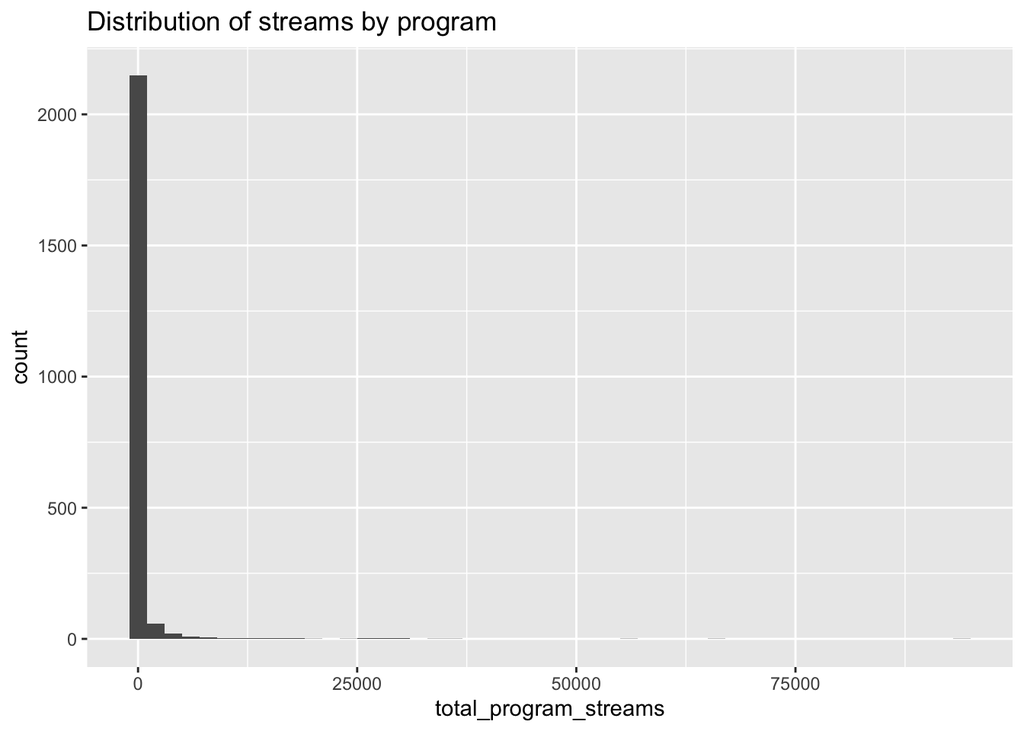

```r
# Visualizing the distribution of streams using a histogram
count_of_streams_by_program <- streaming %>%
  group_by(Content.Channel) %>%
  summarize(total_program_streams = n())

ggplot(count_of_streams_by_program, aes(x=total_program_streams)) + geom_histogram(binwidth = 2000) + labs(title = 'Distribution of streams by program')
```

Clearly, the distribution is very right-skewed, with the vast majority of programs being streamed less than 2,000 times during the 16-month period we are looking at. But just how right-skewed is it?

```r
# Basic summary statistics
# Just how right-skewed is the distribution of streams by program?
mean(count_of_streams_by_program$total_program_streams)
```

```
## [1] 508.3659
```

```r
median(count_of_streams_by_program$total_program_streams)
```

```
## [1] 5
```

With a mean number of 508 streams per program title and median number of only 5, we can see exactly how skewed streaming behavior is toward a select few program titles.

# Clustering by Genre

Now that we have a better understanding of our dataset, it’s time to lay the groundwork for our unsupervised learning task — clustering. Clustering based on what genres of programs viewers like to watch seems like a resonable way to segment users by their viewing preferences. Genre information was pulled manually from pbs.org/video.

### Feature engineering

Now we’ll map genre information to the top 50 programs. If genre information had been included in the original dataset, or if PBS had an API for their backend media management system such that the genre information for each program could be scraped from the web, this section would have been far less tedious.

```r
# Creating new boolean "Genre" variables based on the top 50 programs ranked by total sum of streams

streaming_by_genre <- streaming %>%
  mutate(Drama = ifelse(Content.Channel %in% c("All Creatures Great and Small", "Grantchester", "Miss Scarlet & The Duke", "Unforgotten", "Atlantic Crossing", "Professor T", "Around the World in 80 Days", "Call the Midwife", "Downton Abbey", "Sanditon", "Seaside Hotel", "Frankie Drake Mysteries", "Vienna Blood", "Poldark", "Halifax: Retribution", "Baptiste", "Thou Shalt Not Kill", "BroadChurch", "Endeavour", "Roadkill", "Jamestown", "No Second Chance", "The Long Song", "Victoria", "Guilt", "Land Girls", "Us", "The Trouble With Maggie Cole", "The Indian Doctor", "RFDS: Royal Flying Doctor Service", "Line of Separation", "COBRA"), 1, 0),
         ScienceandNature = ifelse(Content.Channel %in% c("NOVA", "Nature"), 1, 0),
         Culture = ifelse(Content.Channel %in% c("Finding Your Roots", "Rick Steves' Europe", "This Is Utah", "Lidia Celebrates America"), 1, 0),
         ArtsandMusic = ifelse(Content.Channel %in% c("Great Performances", "Austin City Limits", "The Best of the Joy of Painting with Bob Ross", "Craft in America", "Inside the Met"), 1, 0),
         NewsandPublicAffairs = ifelse(Content.Channel %in% c("PBS NewsHour", "FRONTLINE", "Washington Week", "Amanpour and Company", "The Hinckley Report", "Utah Insight"), 1, 0),
         History = ifelse(Content.Channel %in% c("American Experience", "American Masters", "Secrets of the Dead", "Hemingway", "Muhammad Ali", "Utah History"), 1, 0),
         HomeandHowTo = ifelse(Content.Channel %in% c("This Old House", "Antiques Roadshow", "Ask This Old House"), 1, 0),
         Food = ifelse(Content.Channel %in% c("The Great British Baking Show", "Christopher Kimball's Milk Street Television", "Lidia's Kitchen", "America's Test Kitchen", "A Chef's Life", "Simply Ming", "Cook's Country"), 1, 0),
         IndieFilms = ifelse(Content.Channel %in% c("Independent Lens", "POV", "America Reframed"), 1, 0))

# Look at the new dataset, checking to make sure new variables were created correctly
summary(streaming_by_genre)
```

```
##                       Content.Channel            Device             ID
##  All Creatures Great and Small: 93040   GA Roku     :450404   Min.   :    1
##  PBS NewsHour                 : 66513   TVOS App    :166984   1st Qu.: 5199
##  NOVA                         : 55383   IOS         :147618   Median :10207
##  Finding Your Roots           : 36289   Video Portal:139474   Mean   :10225
##  Grantchester                 : 33134   GA Fire TV  : 84827   3rd Qu.:15343
##  Miss Scarlet & The Duke      : 30873   Samsung TV  : 55914   Max.   :20390
##  (Other)                      :840792   (Other)     :110803
##      Drama        ScienceandNature     Culture         ArtsandMusic
##  Min.   :0.0000   Min.   :0.00000   Min.   :0.00000   Min.   :0.0000
##  1st Qu.:0.0000   1st Qu.:0.00000   1st Qu.:0.00000   1st Qu.:0.0000
##  Median :0.0000   Median :0.00000   Median :0.00000   Median :0.0000
##  Mean   :0.4583   Mean   :0.07163   Mean   :0.04197   Mean   :0.0237
##  3rd Qu.:1.0000   3rd Qu.:0.00000   3rd Qu.:0.00000   3rd Qu.:0.0000
##  Max.   :1.0000   Max.   :1.00000   Max.   :1.00000   Max.   :1.0000
##
##  NewsandPublicAffairs    History         HomeandHowTo          Food
##  Min.   :0.00000      Min.   :0.00000   Min.   :0.00000   Min.   :0.00000
##  1st Qu.:0.00000      1st Qu.:0.00000   1st Qu.:0.00000   1st Qu.:0.00000
##  Median :0.00000      Median :0.00000   Median :0.00000   Median :0.00000
##  Mean   :0.08233      Mean   :0.05305   Mean   :0.03529   Mean   :0.00922
##  3rd Qu.:0.00000      3rd Qu.:0.00000   3rd Qu.:0.00000   3rd Qu.:0.00000
##  Max.   :1.00000      Max.   :1.00000   Max.   :1.00000   Max.   :1.00000
##
##    IndieFilms
##  Min.   :0.00000
##  1st Qu.:0.00000
##  Median :0.00000
##  Mean   :0.01068
##  3rd Qu.:0.00000
##  Max.   :1.00000
##
```

```r
# Check for rows where any of the above programs were not watched
count(streaming_by_genre[rowSums(streaming_by_genre[4:12]) == 0,])
```

```
##        n
## 1 247203
```

Looks like 247,203 streams were of programs not contained in the top 50. In other words, the top 50 programs above accounted for 78% of all streaming during this time period.

```r
# Update streaming_by_genre dataset to reflect only viewers who have watched at least 1 of the above programs
streaming_by_genre <- streaming_by_genre[rowSums(streaming_by_genre[4:12]) > 0,]
```

### Aggregating by unique user identifier (ID)

The source data consists of rows of individual streams, not rows of individual users. To isolate streams by unique user, we need to aggregate by each user’s unique identifier (in this case, the ID column).

```r
# Remove Content.Channel column, also Device column (could consider keeping it in for future iterations); would need to turn it into a dummy variable
streaming_by_genre <- streaming_by_genre[c(-1,-2)]

# Aggregate by ID
streaming_by_genre <- streaming_by_genre %>%
  group_by(ID) %>%
  summarise_each(funs(max))

# Print the first 5 rows of the new dataset to make sure everything looks right
head(streaming_by_genre)
```

```
## # A tibble: 6 × 10
##      ID Drama ScienceandNature Culture ArtsandMusic NewsandPublicAffairs History
##   <int> <dbl>            <dbl>   <dbl>        <dbl>                <dbl>   <dbl>
## 1     1     1                1       0            0                    0       0
## 2     2     1                0       0            1                    1       0
## 3     3     0                1       0            1                    0       0
## 4     4     0                1       0            0                    0       1
## 5     5     0                1       0            1                    1       1
## 6     6     1                1       0            1                    1       1
## # … with 3 more variables: HomeandHowTo <dbl>, Food <dbl>, IndieFilms <dbl>
```

### Clustering

Now we’ll create the cluster assignments and print the cluster centers.

```r
# Isolate only the programs to use for clustering (remove ID column)
streaming_genres <- streaming_by_genre[-1]

# Create clusters
set.seed(123)
genre.clusters <- kmeans(streaming_genres, 7)
genre.clusters$size
```

```
## [1] 3060 6598 1830 2694 2273 1695 1277
```

```r
genre.clusters$centers
```

```
##       Drama ScienceandNature   Culture ArtsandMusic NewsandPublicAffairs
## 1 0.9663399        0.8630719 0.2431373    0.4771242            0.7650327
## 2 1.0000000        0.1262504 0.0000000    0.1136708            0.0841164
## 3 0.0000000        0.4371585 0.1918033    0.1972678            0.3448087
## 4 0.9502598        0.9153675 0.9224202    0.9409800            0.9179659
## 5 0.9925209        0.2516498 0.8790145    0.4232292            0.1794985
## 6 0.9286136        0.8224189 0.3758112    0.4607670            0.4218289
## 7 0.0000000        0.4197338 0.1636648    0.1213782            0.3296789
##     History HomeandHowTo       Food IndieFilms
## 1 0.8251634   0.00000000 0.05261438 0.25588235
## 2 0.1176114   0.03501061 0.03091846 0.05395574
## 3 0.0000000   0.16065574 0.06174863 0.08032787
## 4 0.9610245   0.78544915 0.15961396 0.83593170
## 5 0.5684118   0.10690717 0.06203256 0.13374395
## 6 0.7592920   1.00000000 0.11209440 0.15280236
## 7 1.0000000   0.10180110 0.02427565 0.08770556
```

#### Determining the Number of Clusters

```r
# Use the elbow method to determine the optimal value of k
# Start by decreasing the sample size to make it computationally easier
index <- sample(1:nrow(streaming_genres), floor(nrow(streaming_genres)*0.05))
streaming.subset <- streaming_genres[index,]
wss <- function(k){
  kmeans(streaming.subset, k, nstart = 10)$tot.withinss
}
wss(5)
```

```
## [1] 904.9578
```

```r
kValues <- 2:15
wssvalues <- unlist(lapply(kValues, wss))
wssvalues
```

```
##  [1] 1216.1971 1065.1495  987.3800  890.9896  843.2110  823.3778  778.0585
##  [8]  733.8155  703.7088  679.5483  655.6024  635.6335  601.2736  590.5796
```

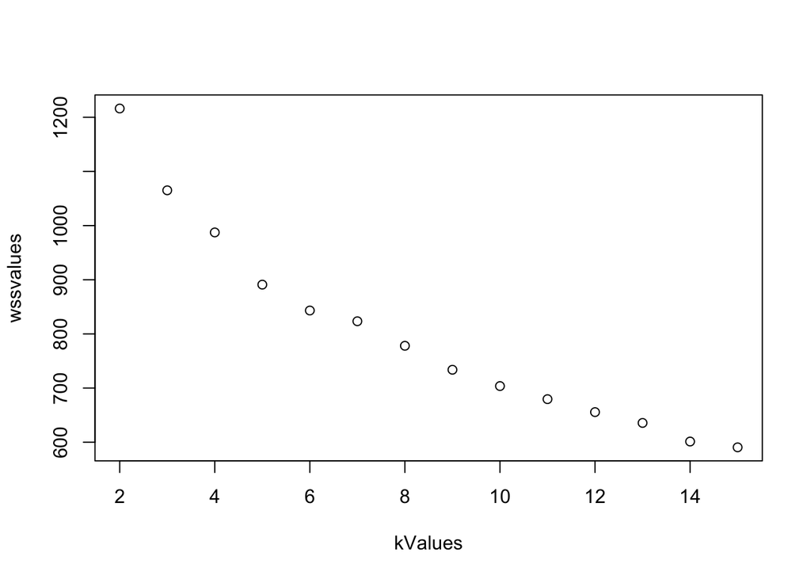

```r
# Plot values against k (making the elbow plot)
plot(kValues, wssvalues)
```

It looks as though 6 or 7 values of k is optimal. However, if we intend to use our new clusters as audience segments, each to receive its own targeted email communication, a good question to ask is: How many different email iterations so we really want to send? If the answer is “fewer emails,” then a smaller value of k may be more appropriate for the business use case.

```r
# finally, add the cluster assignments back into the dataset
streaming_by_genre$cluster <- genre.clusters$cluster

head(streaming_by_genre)
```

```
## # A tibble: 6 × 11
##      ID Drama ScienceandNature Culture ArtsandMusic NewsandPublicAffairs History
##   <int> <dbl>            <dbl>   <dbl>        <dbl>                <dbl>   <dbl>
## 1     1     1                1       0            0                    0       0
## 2     2     1                0       0            1                    1       0
## 3     3     0                1       0            1                    0       0
## 4     4     0                1       0            0                    0       1
## 5     5     0                1       0            1                    1       1
## 6     6     1                1       0            1                    1       1
## # … with 4 more variables: HomeandHowTo <dbl>, Food <dbl>, IndieFilms <dbl>,
## #   cluster <int>
```

## Bonus Section: Clustering by Program Instead of Genre

Can we extract some meaningful insights by creating clusters based on program, and not genre?

```r
# create boolean variables for each of the top 50 programs
streaming_by_program <- streaming %>%
  mutate(AllCreatures = ifelse(Content.Channel == "All Creatures Great and Small", 1, 0),
         NewsHour = ifelse(Content.Channel == "PBS NewsHour", 1, 0),
         NOVA = ifelse(Content.Channel == "NOVA", 1, 0),
         FindingYourRoots = ifelse(Content.Channel == "Finding Your Roots", 1, 0),
         Grantchester = ifelse(Content.Channel == "Grantchester", 1, 0),
         MissScarlet = ifelse(Content.Channel == "Miss Scarlet & The Duke", 1, 0),
         Unforgotten = ifelse(Content.Channel == "Unforgotten", 1, 0),
         AtlanticCrossing = ifelse(Content.Channel == "Atlantic Crossing", 1, 0),
         AntiquesRoadshow = ifelse(Content.Channel == "Antiques Roadshow", 1, 0),
         ProfessorT = ifelse(Content.Channel == "Professor T", 1, 0),
         Nature = ifelse(Content.Channel == "Nature", 1, 0),
         AroundTheWorldin80Days = ifelse(Content.Channel == "Around the World in 80 Days", 1, 0),
         CallTheMidwife = ifelse(Content.Channel == "Call the Midwife", 1, 0),
         DowntonAbbey = ifelse(Content.Channel == "Downton Abbey", 1, 0),
         FRONTLINE = ifelse(Content.Channel == "FRONTLINE", 1, 0),
         Sanditon = ifelse(Content.Channel == "Sanditon", 1, 0),
         SeasideHotel = ifelse(Content.Channel == "Seaside Hotel", 1, 0),
         FrankieDrake = ifelse(Content.Channel == "Frankie Drake Mysteries", 1, 0),
         ViennaBlood = ifelse(Content.Channel == "Vienna Blood", 1, 0),
         AmericanExperience = ifelse(Content.Channel == "American Experience", 1, 0),
         Poldark = ifelse(Content.Channel == "Poldark", 1, 0),
         GreatPerformances = ifelse(Content.Channel == "Great Performances", 1, 0),
         AmericanMasters = ifelse(Content.Channel == "American Masters", 1, 0),
         SecretsoftheDead = ifelse(Content.Channel == "Secrets of the Dead", 1, 0),
         HalifaxRetribution = ifelse(Content.Channel == "Halifax: Retribution", 1, 0),
         Baptiste = ifelse(Content.Channel == "Baptiste", 1, 0),
         ThouShaltNotKill = ifelse(Content.Channel == "Thou Shalt Not Kill", 1, 0),
         Broadchurch = ifelse(Content.Channel == "Broadchurch", 1, 0),
         Endeavour = ifelse(Content.Channel == "Endeavour", 1, 0),
         ThisOldHouse = ifelse(Content.Channel == "This Old House", 1, 0),
         RickSteves = ifelse(Content.Channel == "Rick Steves' Europe", 1, 0),
         IndependentLens = ifelse(Content.Channel == "Independent Lens", 1, 0),
         AustinCityLimits = ifelse(Content.Channel == "Austin City Limits", 1, 0),
         GreatBritishBakingShow = ifelse(Content.Channel == "The Great British Baking Show", 1, 0),
         Hemingway = ifelse(Content.Channel == "Hemingway", 1, 0),
         Roadkill = ifelse(Content.Channel == "Roadkill", 1, 0),
         Jamestown = ifelse(Content.Channel == "Jamestown", 1, 0),
         NoSecondChance = ifelse(Content.Channel == "No Second Chance", 1, 0),
         TheLongSong = ifelse(Content.Channel == "The Long Song", 1, 0),
         Victoria = ifelse(Content.Channel == "Victoria", 1, 0),
         Guilt = ifelse(Content.Channel == "Guilt", 1, 0),
         LandGirls = ifelse(Content.Channel == "Land Girls", 1, 0),
         Us = ifelse(Content.Channel == "Us", 1, 0),
         TroubleWithMaggieCole = ifelse(Content.Channel == "The Trouble With Maggie Cole", 1, 0),
         TheIndianDoctor = ifelse(Content.Channel == "The Indian Doctor", 1, 0),
         RoyalFlyingDoctorService = ifelse(Content.Channel == "RFDS: Royal Flying Doctor Service", 1, 0),
         MuhammadAli = ifelse(Content.Channel == "Muhammad Ali", 1, 0),
         UtahHistory = ifelse(Content.Channel == "Utah History", 1, 0),
         LineofSeparation = ifelse(Content.Channel == "Line of Separation", 1, 0),
         WashingtonWeek = ifelse(Content.Channel == "Washington Week", 1, 0),
         COBRA = ifelse(Content.Channel == "COBRA", 1, 0))

# Look at new dataset, check to make sure new variables were created correctly
summary(streaming_by_program)
```

```
##                       Content.Channel            Device             ID
##  All Creatures Great and Small: 93040   GA Roku     :450404   Min.   :    1
##  PBS NewsHour                 : 66513   TVOS App    :166984   1st Qu.: 5199
##  NOVA                         : 55383   IOS         :147618   Median :10207
##  Finding Your Roots           : 36289   Video Portal:139474   Mean   :10225
##  Grantchester                 : 33134   GA Fire TV  : 84827   3rd Qu.:15343
##  Miss Scarlet & The Duke      : 30873   Samsung TV  : 55914   Max.   :20390
##  (Other)                      :840792   (Other)     :110803
##   AllCreatures        NewsHour            NOVA         FindingYourRoots
##  Min.   :0.00000   Min.   :0.00000   Min.   :0.00000   Min.   :0.00000
##  1st Qu.:0.00000   1st Qu.:0.00000   1st Qu.:0.00000   1st Qu.:0.00000
##  Median :0.00000   Median :0.00000   Median :0.00000   Median :0.00000
##  Mean   :0.08048   Mean   :0.05754   Mean   :0.04791   Mean   :0.03139
##  3rd Qu.:0.00000   3rd Qu.:0.00000   3rd Qu.:0.00000   3rd Qu.:0.00000
##  Max.   :1.00000   Max.   :1.00000   Max.   :1.00000   Max.   :1.00000
##
##   Grantchester      MissScarlet       Unforgotten      AtlanticCrossing
##  Min.   :0.00000   Min.   :0.00000   Min.   :0.00000   Min.   :0.00000
##  1st Qu.:0.00000   1st Qu.:0.00000   1st Qu.:0.00000   1st Qu.:0.00000
##  Median :0.00000   Median :0.00000   Median :0.00000   Median :0.00000
##  Mean   :0.02866   Mean   :0.02671   Mean   :0.02644   Mean   :0.02627
##  3rd Qu.:0.00000   3rd Qu.:0.00000   3rd Qu.:0.00000   3rd Qu.:0.00000
##  Max.   :1.00000   Max.   :1.00000   Max.   :1.00000   Max.   :1.00000
##
##  AntiquesRoadshow    ProfessorT          Nature        AroundTheWorldin80Days
##  Min.   :0.00000   Min.   :0.00000   Min.   :0.00000   Min.   :0.00000
##  1st Qu.:0.00000   1st Qu.:0.00000   1st Qu.:0.00000   1st Qu.:0.00000
##  Median :0.00000   Median :0.00000   Median :0.00000   Median :0.00000
##  Mean   :0.02426   Mean   :0.02385   Mean   :0.02373   Mean   :0.02328
##  3rd Qu.:0.00000   3rd Qu.:0.00000   3rd Qu.:0.00000   3rd Qu.:0.00000
##  Max.   :1.00000   Max.   :1.00000   Max.   :1.00000   Max.   :1.00000
##
##  CallTheMidwife    DowntonAbbey       FRONTLINE          Sanditon
##  Min.   :0.0000   Min.   :0.00000   Min.   :0.00000   Min.   :0.0000
##  1st Qu.:0.0000   1st Qu.:0.00000   1st Qu.:0.00000   1st Qu.:0.0000
##  Median :0.0000   Median :0.00000   Median :0.00000   Median :0.0000
##  Mean   :0.0222   Mean   :0.02015   Mean   :0.01654   Mean   :0.0164
##  3rd Qu.:0.0000   3rd Qu.:0.00000   3rd Qu.:0.00000   3rd Qu.:0.0000
##  Max.   :1.0000   Max.   :1.00000   Max.   :1.00000   Max.   :1.0000
##
```

[output cut: 65 more lines]

```
##  Min.   :0.000000   Min.   :0.000000   Min.   :0.000000   Min.   :0.000000
##  1st Qu.:0.000000   1st Qu.:0.000000   1st Qu.:0.000000   1st Qu.:0.000000
##  Median :0.000000   Median :0.000000   Median :0.000000   Median :0.000000
##  Mean   :0.004307   Mean   :0.003714   Mean   :0.003657   Mean   :0.003586
##  3rd Qu.:0.000000   3rd Qu.:0.000000   3rd Qu.:0.000000   3rd Qu.:0.000000
##  Max.   :1.000000   Max.   :1.000000   Max.   :1.000000   Max.   :1.000000
##
##      COBRA
##  Min.   :0.000000
##  1st Qu.:0.000000
##  Median :0.000000
##  Mean   :0.003495
##  3rd Qu.:0.000000
##  Max.   :1.000000
##
```

```r
# check for rows where programs other than those in the top 50 programs seen above were streamed
count(streaming_by_program[rowSums(streaming_by_program[4:54]) == 0,])
```

```
##        n
## 1 260250
```

```r
# update streaming_by_program dataset to reflect only viewers who have watched at least 1 of the above programs
streaming_by_program <- streaming_by_program[rowSums(streaming_by_program[4:54]) > 0,]
```

### Aggregating by unique user identifier (ID)

The source data consists of rows of individual streams, not rows of individual users. To isolate streams by unique user, we need to aggregate by each user’s unique identifier (in this case, the ID column).

```r
# Remove Content.Channel column, also Device column (could consider keeping it in for future iterations)
# would need to turn it into a dummy variable
streaming_by_program <- streaming_by_program[c(-1,-2)]

# aggregate by ID
streaming_by_program <- streaming_by_program %>%
  group_by(ID) %>%
  summarise_each(funs(max))

# check to make sure everything looks right
head(streaming_by_program)
```

```
## # A tibble: 6 × 52
##      ID AllCreatures NewsHour  NOVA FindingYourRoots Grantchester MissScarlet
##   <int>        <dbl>    <dbl> <dbl>            <dbl>        <dbl>       <dbl>
## 1     1            0        0     1                0            0           0
## 2     2            1        0     0                0            0           1
## 3     3            0        0     0                0            0           0
## 4     4            0        0     1                0            0           0
## 5     5            0        1     1                0            0           0
## 6     6            1        1     1                0            1           0
## # … with 45 more variables: Unforgotten <dbl>, AtlanticCrossing <dbl>,
## #   AntiquesRoadshow <dbl>, ProfessorT <dbl>, Nature <dbl>,
## #   AroundTheWorldin80Days <dbl>, CallTheMidwife <dbl>, DowntonAbbey <dbl>,
## #   FRONTLINE <dbl>, Sanditon <dbl>, SeasideHotel <dbl>, FrankieDrake <dbl>,
## #   ViennaBlood <dbl>, AmericanExperience <dbl>, Poldark <dbl>,
## #   GreatPerformances <dbl>, AmericanMasters <dbl>, SecretsoftheDead <dbl>,
## #   HalifaxRetribution <dbl>, Baptiste <dbl>, ThouShaltNotKill <dbl>, …
```

### Clustering

Now we’ll create the cluster assignments and print the cluster centers.

```r
# isolate only the programs to use for clustering (remove ID)
streaming_programs <- streaming_by_program[-1]

# run cluster
set.seed(123)
clusters <- kmeans(streaming_programs, 5)
clusters$size
```

```
## [1] 2779 1676 7729 4364 2815
```

```r
clusters$centers
```

```
##   AllCreatures  NewsHour      NOVA FindingYourRoots Grantchester MissScarlet
## 1    0.5098956 0.4778697 0.8736956        0.5847427    0.1234257   0.3008276
## 2    0.9510740 0.6115752 0.8902148        0.7559666    0.6694511   0.8383055
## 3    0.0000000 0.1258895 0.2305602        0.1167033    0.0535645   0.1159270
## 4    0.9997709 0.1058662 0.1824015        0.1484876    0.1136572   0.3345555
## 5    0.8625222 0.2127886 0.3989343        0.3019538    0.5509769   0.7801066
##   Unforgotten AtlanticCrossing AntiquesRoadshow ProfessorT    Nature
## 1  0.20079165        0.2792371       0.46095718 0.16156891 0.6750630
## 2  0.77684964        0.8156325       0.66050119 0.76968974 0.7828162
## 3  0.09406133        0.1089404       0.08034675 0.06689093 0.1275715
## 4  0.09486709        0.1883593       0.09303391 0.05957837 0.1553621
## 5  0.59005329        0.6920071       0.19076377 0.51154529 0.2696270
##   AroundTheWorldin80Days CallTheMidwife DowntonAbbey  FRONTLINE   Sanditon
## 1             0.26304426     0.19611371   0.08780137 0.63476071 0.13062253
## 2             0.74164678     0.60262530   0.21599045 0.78818616 0.40513126
```

[output cut: 45 more lines]

Notice that the cluster centers become much less easy to understand when we’ve drilled down to the program level instead of the higher-order genre level. Perhaps market-basket analysis would be better here.

#### Determining the Number of Clusters

```r
# Use elbow method to determine the optimal value of k
# start by decreasing the sample size to make it computationally easier
index <- sample(1:nrow(streaming_programs), floor(nrow(streaming_programs)*0.05))
streaming.subset <- streaming_programs[index,]
wss <- function(k){
  kmeans(streaming.subset, k, nstart = 10)$tot.withinss
}
wss(5)
```

```
## [1] 4455.468
```

```r
kValues <- 2:15
wssvalues <- unlist(lapply(kValues, wss))
wssvalues
```

```
##  [1] 5012.803 4788.150 4585.557 4455.468 4373.483 4283.094 4218.865 4172.584
##  [9] 4100.902 4078.003 4040.160 4011.418 3975.920 3917.427
```

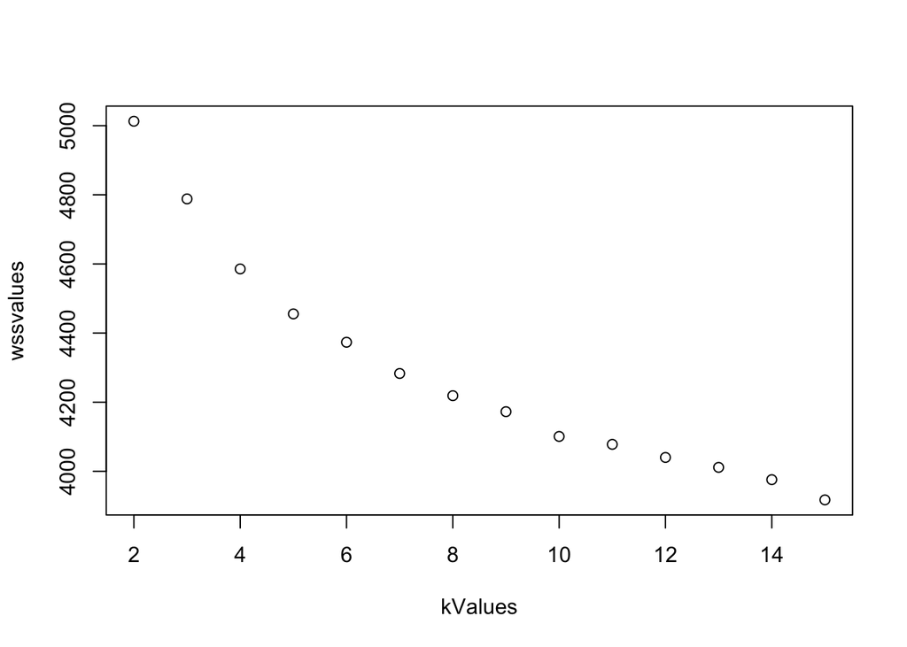

```r
# plot values against k (making the elbow plot)
plot(kValues, wssvalues)
```

## Conclusions and Future Iterations

We have now successfully segmented the PBS Utah donor audience by their viewing behavior. With cluster assignments added back in to the dataset, these viewers could then be served more targeted email communications based on their assigned cluster, either when grouped by genre or by program.

However, the lack of readily available genre information for each program title means that a number of viewers would be left without cluster assignments. As there are thousands of unique program titles available through the PBS Video App, manually adding genre information program by program is not a feasible solution. More information is needed from PBS for this project to truly be considered complete.